# Aksaray Genelinde Seçim Sonuçları

secimler R paketi otomatik raporlama

2017-02-04

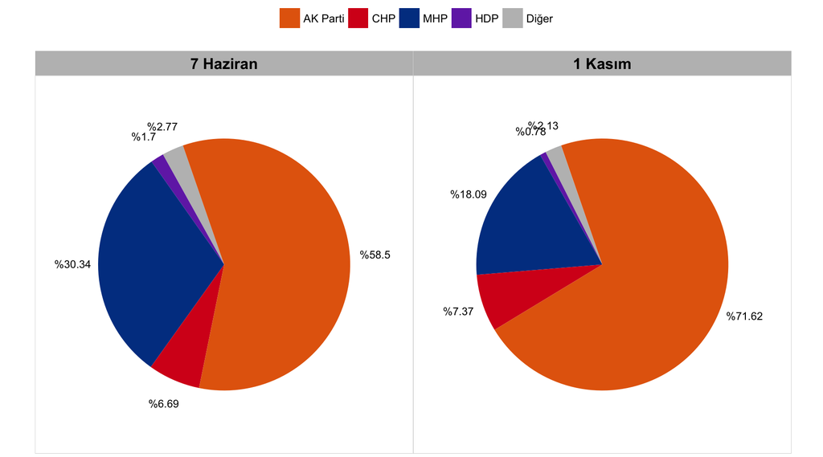

7 Haziran ve 1 Kasım 2015 genel seçimlerinin oy oranı bazında karşılaştırması.

# 7 Haziran 2015 Genel Seçimi Özet Bilgiler

Aksaray ilinde bu seçimde 7 ilçe, 92 mahalle, 60 belde, 177 köy, 1 cezaevi ve toplamda 855 seçim sandığı bulunmaktadır. İl içerisinde toplam 254.762 kayıtlı seçmen bulunmaktadır. 209.965 seçmen oy kullanmış, geçerli oy sayısı ise 204.945 olmuştur. Seçime katılım oranı %82,42 olarak gerçekleşmiştir.

Toplam sonuçlarda AK Parti %58,5, CHP %6,69, MHP %30,34, HDP %1,7 ve diğer partiler ile bağımsızlar %2,77 oy oranına sahip olmuşlardır. Aksaray, 81 il arasından, partilerin kendi içindeki oy oranları sıralamalarına göre AK Parti’nin 8, CHP’nin 63, MHP’nin 6 ve HDP’nin 56. sıradaki ili olmuştur.[^1]

İl içerisinde seçim çevrelerinin partilere oy oranı dağılımı aşağıdaki grafikte gösterilmiştir.

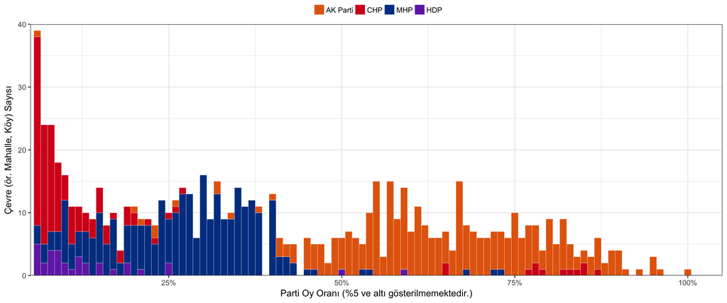

7 Haziran seçimlerinde partilerin seçim çevrelerinden aldıkları oy oranları histogramı.

# 1 Kasım 2015 Genel Seçimi Özet Bilgiler

Aksaray ilinde bu seçimde 7 ilçe, 92 mahalle, 60 belde, 177 köy, 1 cezaevi ve toplamda 860 seçim sandığı bulunmaktadır. İl içerisinde toplam 254.360 kayıtlı seçmen bulunmaktadır. 214.971 seçmen oy kullanmış, geçerli oy sayısı ise 211.424 olmuştur. Seçime katılım oranı %84,51 olarak gerçekleşmiştir.

Toplam sonuçlarda AK Parti %71,62, CHP %7,37, MHP %18,09, HDP %0,78 ve diğer partiler ile bağımsızlar %2,13 oy oranına sahip olmuşlardır. Aksaray, 81 il arasından, partilerin kendi içindeki oy oranları sıralamalarına göre AK Parti’nin 5, CHP’nin 62, MHP’nin 19 ve HDP’nin 63. sıradaki ili olmuştur.[^2]

İl içerisinde seçim çevrelerinin partilere oy oranı dağılımı aşağıdaki grafikte gösterilmiştir.

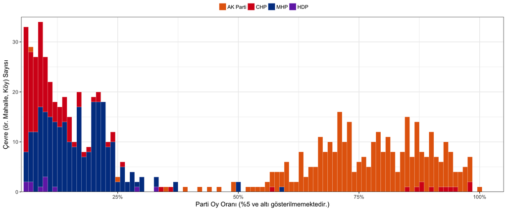

1 Kasım seçimlerinde partilerin seçim çevrelerinden aldıkları oy oranları histogramı.

# İlçe Bazında Karşılaştırmalar

Aşağıdaki bilgilerde ilçe bazında özet grafikler bulunmaktadır. Bu grafiklerde her ilçenin toplam kayıtlı seçmen sayısı, geçerli oy sayısı, geçersiz oy sayısı ve barajı aşan partilerin (AK Parti, CHP, MHP ve HDP) oy oranları bulunmaktadır. İlçeler hakkında detaylı bilgi edinmek için ilçelerin kendi raporlarını inceleyebilirsiniz. *(Detaylı bilgi dökümanın sonunda yer almaktadır.)*

## Seçmen İstatistikleri

Kayıtlı seçmen sayısındaki değişim en yüksek oranda Eskil (+%0.28) ilçesinde ve en düşük oranda Sarıyahşi (-%2.91) ilçesinde görülmektedir. Seçime katılım oranında değişim ise en yüksek oranda Gülağaç (+%3.14) ilçesinde ve en düşük oranda Sarıyahşi (-%2.64) ilçesinde görülmektedir.

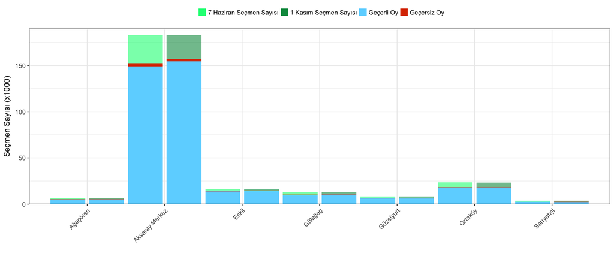

İlçelerin kayıtlı seçmen, geçerli ve geçersiz oy sayıları.

## Parti Oy Oranları

### AK Parti

AK Parti, 7 Haziran seçimlerinde Aksaray ilçeleri arasında en yüksek oy oranını Ağaçören (%64.03), en düşük oy oranını Gülağaç (%55.41) ilçelerinde görmüştür. 1 Kasım seçimlerinde ise en yüksek oy oranını Eskil (%77.78), en düşük oy oranını Sarıyahşi (%64.2) ilçelerinde görmüştür. İki seçim arasında oy oranlarındaki değişimi sıralayacak olursak; en yüksek oranda değişim Eskil (+%14.89) ilçesinde ve en düşük oranda Sarıyahşi (+%6.33) ilçesinde görülmektedir.

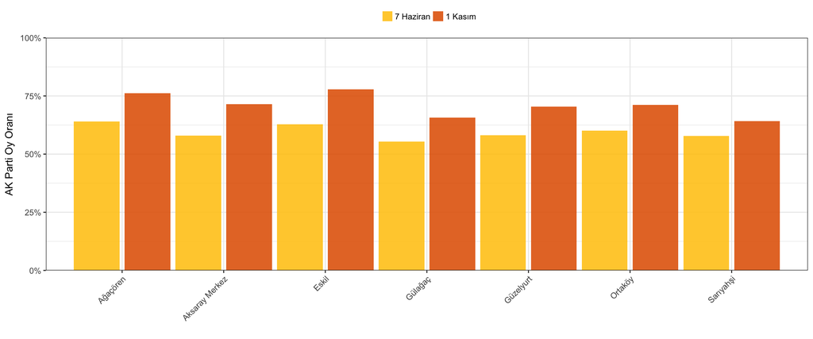

AK Parti’nin ilçelerde aldığı oy oranları.

### CHP

CHP, 7 Haziran seçimlerinde Aksaray ilçeleri arasında en yüksek oy oranını Gülağaç (%16.81), en düşük oy oranını Aksaray Merkez (%5.62) ilçelerinde görmüştür. 1 Kasım seçimlerinde ise en yüksek oy oranını Gülağaç (%19.16), en düşük oy oranını Ağaçören (%5.1) ilçelerinde görmüştür. İki seçim arasında oy oranlarındaki değişimi sıralayacak olursak; en yüksek oranda değişim Gülağaç (+%2.35) ilçesinde ve en düşük oranda Ağaçören (-%0.56) ilçesinde görülmektedir.

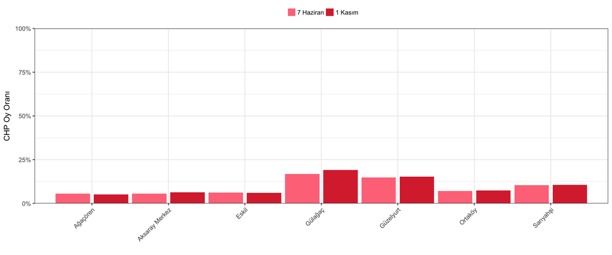

CHP’nin ilçelerde aldığı oy oranları.

### MHP

MHP, 7 Haziran seçimlerinde Aksaray ilçeleri arasında en yüksek oy oranını Aksaray Merkez (%31.92), en düşük oy oranını Gülağaç (%22.4) ilçelerinde görmüştür. 1 Kasım seçimlerinde ise en yüksek oy oranını Sarıyahşi (%19.93), en düşük oy oranını Güzelyurt (%11.61) ilçelerinde görmüştür. İki seçim arasında oy oranlarındaki değişimi sıralayacak olursak; en yüksek oranda değişim Sarıyahşi (-%5.83) ilçesinde ve en düşük oranda Eskil (-%13.2) ilçesinde görülmektedir.

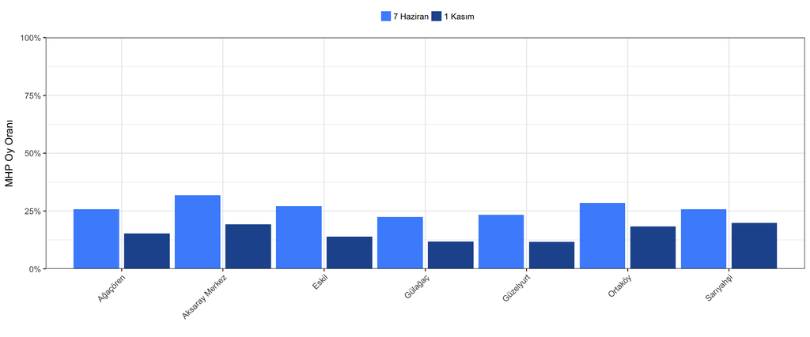

MHP’nin ilçelerde aldığı oy oranları.

### HDP

HDP, 7 Haziran seçimlerinde Aksaray ilçeleri arasında en yüksek oy oranını Aksaray Merkez (%1.97), en düşük oy oranını Ağaçören (%0.33) ilçelerinde görmüştür. 1 Kasım seçimlerinde ise en yüksek oy oranını Aksaray Merkez (%0.92), en düşük oy oranını Ağaçören (%0.1) ilçelerinde görmüştür. İki seçim arasında oy oranlarındaki değişimi sıralayacak olursak; en yüksek oranda değişim Ağaçören (-%0.23) ilçesinde ve en düşük oranda Aksaray Merkez (-%1.05) ilçesinde görülmektedir.

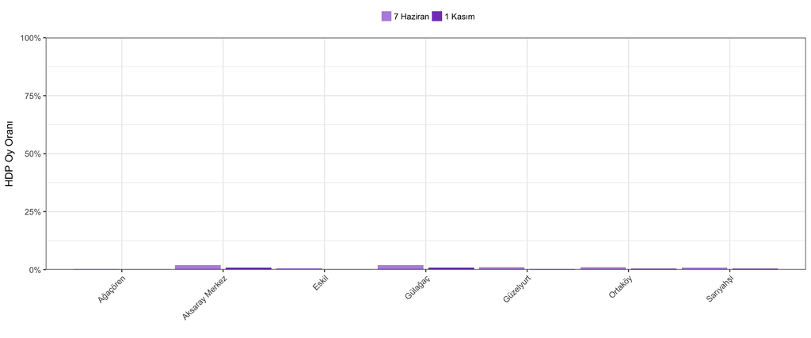

HDP’nin ilçelerde aldığı oy oranları.

# Bilinmesi Gerekenler

- Bu döküman otomatik olarak oluşturulmuştur.
- Dökümanın amacı R ile veri analizi, görselleştirme ve otomatik raporlama konusunda bir eğitim örneği oluşturmaktır.
- Bu dökümanı oluşturmakta kullanılan veriler 7 Haziran ve 1 Kasım’a ait sandık bazında seçim sonucu verilerinden oluşmaktadır. Veriler TÜİK vasıtasıyla YSK kesin seçim sonuçlarından elde edilmiştir.
- Veriler veya hesaplamalarda yanlışlıklar olabilir. Veriler ve analizlerle ilgili herhangi bir sorumluluk kabul edilmemektedir.
- İlgili veri setleri ve analizlere `secimler` R paketi vasıtasıyla ulaşılabilir. Paket hala geliştirme aşamasında olup sürekli güncellenmektedir. https://github.com/berkorbay/secimler adresinden pakete ulaşılabilir ve yükleme talimatları görülebilir.
- Paketin yazarına (Berk Orbay) http://berkorbay.me adresinden ulaşabilirsiniz.
[^1]: Örneğin, AK Parti 7 ilde daha yüksek, 73 ilde ise daha düşük oy oranı görmüştür.
[^2]: Örneğin, AK Parti 4 ilde daha yüksek, 76 ilde ise daha düşük oy oranı görmüştür.